# python可视化模板

## 加载模块及数据导入

```python
import pandas as pd
import matplotlib.pyplot as plt
import seaborn as sns
import numpy as np
#解决中文显示问题
from pylab import *
mpl.rcParams['font.sans-serif'] = ['SimHei'] #用来正常显示中文标签
plt.rcParams['axes.unicode_minus'] = False  #用来正常显示负号
```

```python
mask = pd.read_csv('mask.csv',encoding="gbk")   #数据来源狗熊会
mask.head()
```

|  | 名称 | 价格 | 月销量 | 评价数 | 店铺所在地 | 适合肤质 | 产地 | 补水保湿 | 美白提亮 | 控油祛痘 | 清洁毛孔 | 提拉紧致 |
| --- | --- | --- | --- | --- | --- | --- | --- | --- | --- | --- | --- | --- |
| 0 | ANGLEE | 254.0 | 40 | 3133 | 湖南 | 任何肤质 | 中国 | 1 | 1 | 0 | 0 | 0 |
| 1 | ANGLEE | 350.0 | 62 | 876 | 浙江 | 任何肤质 | 中国 | 1 | 1 | 0 | 0 | 0 |
| 2 | ANGLEE | 284.9 | 12 | 16 | 浙江 | 任何肤质 | 中国 | 1 | 0 | 1 | 1 | 0 |
| 3 | BF | 289.0 | 32 | 175 | 英国 | 任何肤质 | 中国 | 1 | 0 | 0 | 0 | 0 |
| 4 | BSR | 379.9 | 1407 | 13870 | 安徽 | 任何肤质 | 中国 | 1 | 0 | 0 | 0 | 0 |

```python
mask.info()
```

```
<class 'pandas.core.frame.DataFrame'>
RangeIndex: 794 entries, 0 to 793
Data columns (total 12 columns):
名称       794 non-null object
价格       794 non-null float64
月销量      794 non-null int64
评价数      794 non-null int64
店铺所在地    794 non-null object
适合肤质     794 non-null object
产地       794 non-null object
补水保湿     794 non-null int64
美白提亮     794 non-null int64
控油祛痘     794 non-null int64
清洁毛孔     794 non-null int64
提拉紧致     794 non-null int64
dtypes: float64(1), int64(7), object(4)
memory usage: 74.5+ KB
```

```python
print(mask['产地'].unique())
print(mask['店铺所在地'].unique())
print(mask['适合肤质'].unique())
```

```
['中国' '日本' '韩国' '美国' '英国' '其他/other']
['湖南' '浙江' '英国' '安徽' '广东' '湖北' '江苏' '上海' '江西' '北京' '海外' '天津' '山东' '河南'
 '新加坡' '河北' '辽宁' '四川' '重庆' '福建' '内蒙古' '海南' '云南' '广西' '陕西' '黑龙江']
['任何肤质' '干性肤质' '油性及混合性肤质' '中性及干性肤质' '混合型肤质' '敏感性肤质' '中性肤质' '油性肤质']
```

店铺所在地的分类中，“英国”、“新加坡”与“海外”有重叠

```python
#店铺所在地为“英国”或“新加坡”的数据，更改为“海外”
mask.loc[mask.店铺所在地 == '英国','店铺所在地']= '海外'
mask.loc[mask.店铺所在地 == '新加坡','店铺所在地'] = '海外'
print(mask['店铺所在地'].unique())
```

```
['湖南' '浙江' '海外' '安徽' '广东' '湖北' '江苏' '上海' '江西' '北京' '天津' '山东' '河南' '河北'
 '辽宁' '四川' '重庆' '福建' '内蒙古' '海南' '云南' '广西' '陕西' '黑龙江']
```

```python
mask.loc[mask.产地 == '其他/other','产地'] = '其他'
```

```python
mask.loc[mask.适合肤质 != '任何肤质','适合肤质'] = '其他'
```

## 可视化

### 工具

#### 调色板

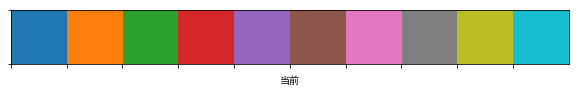

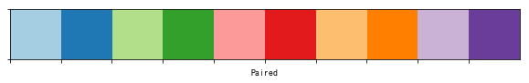

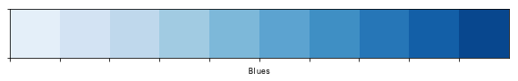

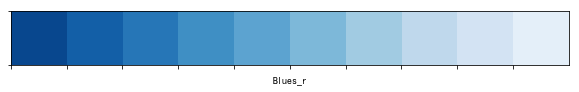

```python
sns.palplot(sns.color_palette())
plt.xlabel('当前')
sns.palplot(sns.color_palette("Paired", 10))
plt.xlabel('Paired')
# sns.palplot(sns.color_palette("BrBG", 10))
# plt.xlabel('BrBG')
# sns.palplot(sns.color_palette("Set1", 10))
# plt.xlabel('Set1')
# sns.palplot(sns.color_palette("Set2", 10))
# plt.xlabel('Set2')
# sns.palplot(sns.color_palette("Set3", 10))
# plt.xlabel('Set3')
# sns.palplot(sns.color_palette("hls", 10))
# plt.xlabel('hls')
# sns.palplot(sns.color_palette("husl", 10))
# plt.xlabel('husl')

#渐变色
sns.palplot(sns.color_palette("Blues", 10))
plt.xlabel('Blues')
sns.palplot(sns.color_palette("Blues_r", 10))
plt.xlabel('Blues_r')
# sns.palplot(sns.color_palette("Greens_r", 10))
# plt.xlabel('Greens_r')
# sns.palplot(sns.color_palette("Reds_r", 10))
# plt.xlabel('Reds_r')
```

#### 多子图

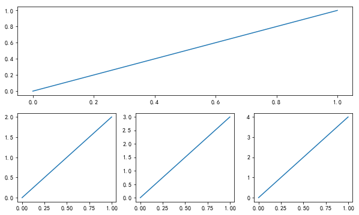

```python
plt.figure(figsize=(10,6))
plt.subplot(2,1,1)
plt.plot([0,1],[0,1])

plt.subplot(2,3,4)
plt.plot([0,1],[0,2])

plt.subplot(235)
plt.plot([0,1],[0,3])

plt.subplot(236)
plt.plot([0,1],[0,4])

plt.show()  # 展示
```

#### 双轴

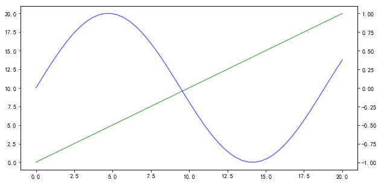

```python
import numpy as np
x = np.linspace(0,20)
y1 = np.linspace(0,20)
y2 = np.sin(x/3)

fig,ax1=plt.subplots(figsize = (10,5))
ax1.plot(x,y1,c='g',alpha=0.6)
ax2 = ax1.twinx() ##双轴
ax2.plot(x,y2,c='b',alpha=0.6)
```

### 散点图

```python
#help(plt.plot)
```

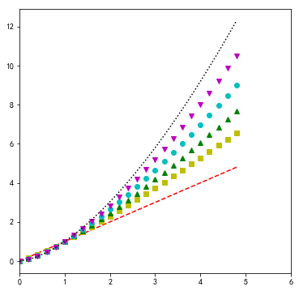

```python
plt.figure(figsize=(6,6))
x = np.arange(0, 5, 0.2)
plt.xlim((0,6)) #设置x轴范围，y轴同理
#'r--'首字母代表颜色，后面符号代表形状
plt.plot(x, x, 'r--', x, x**1.2, 'ys', x, x**1.3, 'g^',x,x**1.4,'co',x,x**1.5,'mv',x,x**1.6,'k:')
plt.show()
```

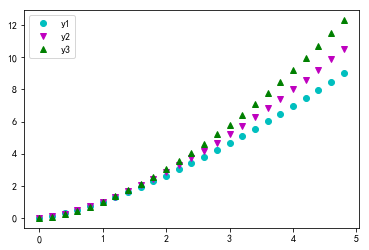

```python
#添加图例
plt.plot(x,x**1.4,'co',label='y1')
plt.plot(x,x**1.5,'mv',label='y2')
plt.plot(x,x**1.6,'g^',label='y3')
plt.legend()
plt.show()
```

### 条形图

#### sns.countplot计数条形图

countplot(x=None, y=None, hue=None, data=None, order=None, hue_order=None, orient=None, color=None, palette=None, saturation=0.75, dodge=True, ax=None, **kwargs)

```python
#help(sns.countplot)
```

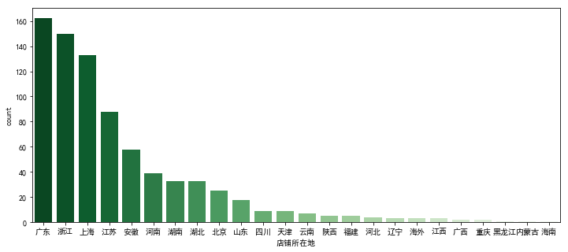

```python
plt.figure(figsize=(12,5))
sns.countplot('店铺所在地',data=mask,order = mask['店铺所在地'].value_counts().index,palette='Greens_r')
```

#### sns.barplot

barplot(x=None, y=None, hue=None, data=None, order=None, hue_order=None, estimator=<function mean at 0x000001E8E4BE0268>, ci=95, n_boot=1000, units=None, orient=None, color=None, palette=None, saturation=0.75, errcolor='.26', errwidth=None, capsize=None, dodge=True, ax=None, **kwargs)

ci表示置信区间；

estimator = mean表示取各类的均值；median表示取各类的中位数；

指定color来改成单一颜色；palette指定调色板，saturation=0.5改变颜色饱和度；

hue指定分类变量；

order表示x的顺序；hue_order指定hue的顺序；

orient = "h"表示绘制水平horizontal条形图；

errcolor = 'blue',指定误差棒的颜色； errwidth=2,指定误差棒的线宽；capsize = 0.05 指定误差棒两端线条的宽度；

```python
#help(sns.barplot)
```

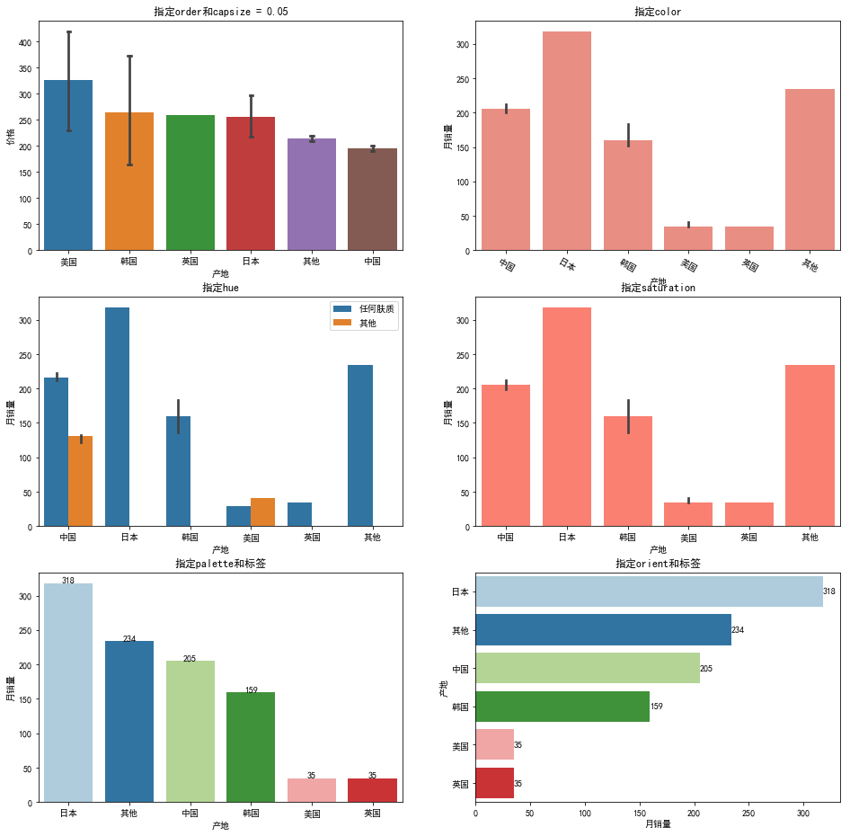

```python
from numpy import median

fig=plt.figure(figsize=(16,16))
ax=fig.add_subplot(3,2,1)
sns.barplot(x="产地", y="价格",data=mask, estimator=mean,ci=75,order=['美国', '韩国','英国','日本', '其他','中国'],capsize = 0.05)
plt.title('指定order和capsize = 0.05')

ax=fig.add_subplot(3,2,2)
sns.barplot(x="产地", y="月销量", data=mask, estimator=median,ci=20,color="salmon")
plt.xticks(rotation=-30) #旋转标签
plt.title('指定color')

ax=fig.add_subplot(3,2,3)
sns.barplot(x="产地", y="月销量",hue="适合肤质", data=mask, estimator=median,ci=20)
plt.title('指定hue')
plt.legend(loc='upper right')

ax=fig.add_subplot(3,2,4)
sns.barplot(x="产地", y="月销量", data=mask, estimator=median,ci=20,color="salmon",saturation=1.2)
plt.title('指定saturation')

ax=fig.add_subplot(3,2,5)
bardata = mask[['产地','月销量']].groupby(['产地']).median().sort_values(by='月销量',ascending = False).reset_index()
g = sns.barplot(x="产地", y="月销量",data=bardata, palette="Paired")
for index,row in bardata.iterrows():
    g.text(row.name,row.月销量,int(row.月销量),color="black",ha="center") #ha调整位置
plt.title('指定palette和标签')

ax=fig.add_subplot(3,2,6)
g = sns.barplot(x="月销量", y="产地",data=bardata, palette="Paired",orient = "h")
for index,row in bardata.iterrows():
    g.text(row.月销量,row.name,int(row.月销量),color="black",va="center") #va调整位置
plt.title('指定orient和标签')##注意改变x和y

#plt.savefig('bar.png',dpi=500)
plt.show()
```

#### plt.bar

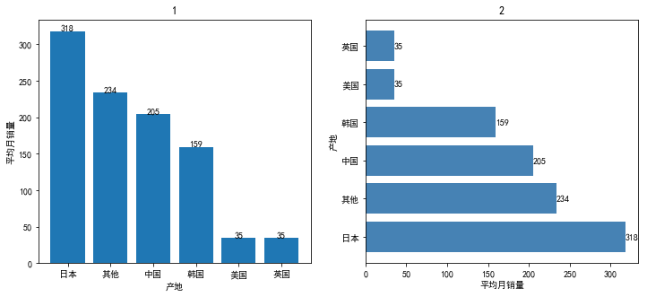

```python
fig=plt.figure(figsize=(12,5))
ax=fig.add_subplot(1,2,1)
ax.bar(x=bardata.产地,height=bardata.月销量)
for index,row in bardata.iterrows():
    ax.text(row.name,row.月销量,int(row.月销量),color="black",ha="center") #ha调整位置
ax.set_title('1')
ax.set_ylabel('平均月销量')
ax.set_xlabel('产地')


'''水平条形图barh'''
ax=fig.add_subplot(1,2,2)
ax.barh(y = range(bardata.shape[0]),width = bardata.月销量,tick_label = bardata.产地,color = 'steelblue')
for index,row in bardata.iterrows():
    ax.text(row.月销量,row.name,int(row.月销量),color="black",va="center") #va调整位置
ax.set_title('2')
ax.set_ylabel('产地')
ax.set_xlabel('平均月销量')
plt.show()
```

### 箱线图

#### boxplot

boxplot(x=None, y=None, hue=None, data=None, order=None, hue_order=None, orient=None, color=None, palette=None, saturation=0.75, width=0.8, dodge=True, fliersize=5, linewidth=None, whis=1.5, notch=False, ax=None, **kwargs)

width：float，箱的宽度  
notch = True表示以凹槽显示中位数的置信区间；  
fliersize：float，离群值点的大小；  
whis：float，离群值范围（Q3+whis*IQR,+∞)和(-∞,Q1-whis*IQR)

```python
#help(sns.boxplot)
```

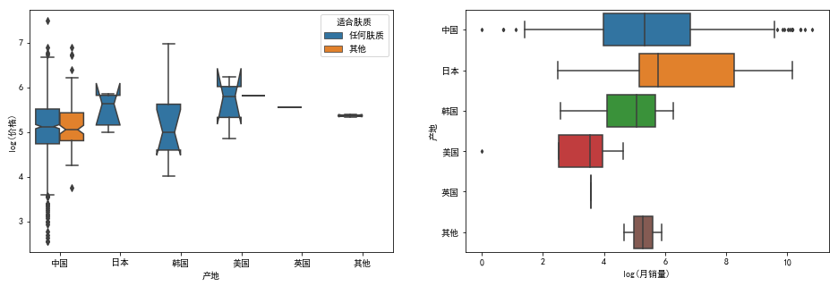

```python
fig=plt.figure(figsize=(16,5))
ax=fig.add_subplot(1,2,1)
sns.boxplot(data=mask,x='产地',y=log(mask['价格']),hue='适合肤质',notch = True) #中位数置信区间
plt.ylabel('log(价格)')
ax=fig.add_subplot(1,2,2)
sns.boxplot(data=mask,x=log(mask['月销量']),y='产地',orient = "h",whis=1,fliersize=3)
plt.xlabel('log(月销量)')
#plt.savefig('box.png',dpi=500)
```

#### boxenplot

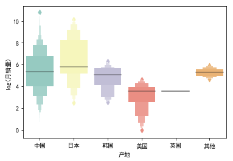

```python
'''加强版箱线图'''
#help(sns.boxenplot)

sns.boxenplot(x='产地',y=log(mask['月销量']),data=mask,palette="Set3")
plt.ylabel('log(月销量)')
#plt.savefig('box.png',dpi=500)
```

#### swarmplot

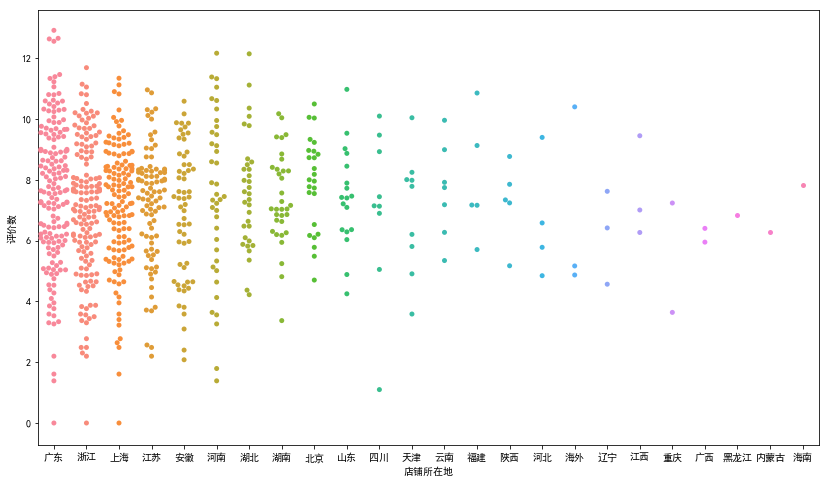

```python
'''美化版小提琴图'''
#help(sns.swarmplot)

plt.figure(figsize=(14,8))
sns.swarmplot(x = '店铺所在地', y=log(mask['评价数']), data = mask,order = mask['店铺所在地'].value_counts().index)
```

### 直方图

distplot(a, bins=None, hist=True, kde=True, rug=False, fit=None, hist_kws=None, kde_kws=None, rug_kws=None, fit_kws=None, color=None, vertical=False, norm_hist=False, axlabel=None, label=None, ax=None)

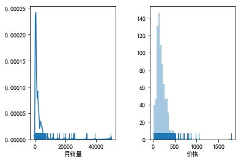

```python
fig,axes=plt.subplots(1,2)      #加入参数sharey=True表示公用y坐标
plt.subplots_adjust(wspace=0.4) #子图间距
sns.distplot(mask['月销量'],rug=True,ax=axes[0],hist=False) #去除直方
sns.distplot(mask['价格'],rug=True,ax=axes[1],kde=False)    #去除核密度曲线
```

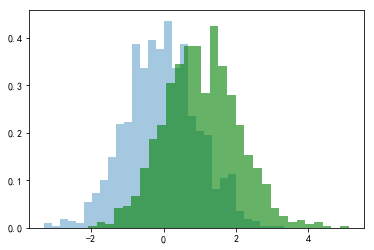

```python
#help(plt.hist)
import numpy as np
x = np.random.normal(0,1,1000)
y = np.random.normal(1,1,1000)
plt.hist(x,bins=30,density=True,alpha=0.4)
plt.hist(y,bins=30,density=True,color='g',alpha=0.6)
plt.show()
```

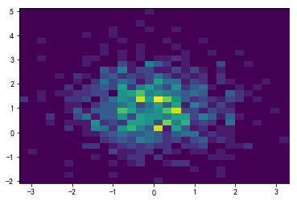

```python
#双直方图
plt.hist2d(x,y,bins=30)
plt.show()
```

### 饼图

pie(x, explode=None, labels=None, colors=None, autopct=None, pctdistance=0.6, shadow=False, labeldistance=1.1, startangle=None, radius=None, counterclock=True, wedgeprops=None, textprops=None, center=(0, 0), frame=False, rotatelabels=False, *, data=None)

autopct设置数据标签；pctdistance数据标签的距离圆心位置：0~1；  
labeldistance: label与圆心距离>1;  
explode: 饼与圆心的距离(列表形式)  
startangle起始角度；  
shadow=True增加阴影，立体效果；

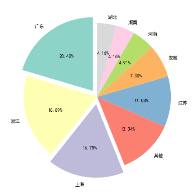

```python
target_list = list(mask['店铺所在地'].value_counts()[9:].index)
mask.loc[mask['店铺所在地'].apply(lambda x: x in target_list),'店铺所在地'] = '其他'

ex = [0.1,0,0.1,0,0,0,0,0,0] #第一个&第三个单独出来，距离圆心0.1
plt.figure(figsize=(7,7))
mask['店铺所在地'].value_counts().plot.pie(autopct = '%1.2f%%',startangle=90,explode=ex,colors=sns.color_palette("Set3", 10))
plt.ylabel('')
#plt.savefig('7店铺所在地饼图.png',dpi=200)
plt.show()
```

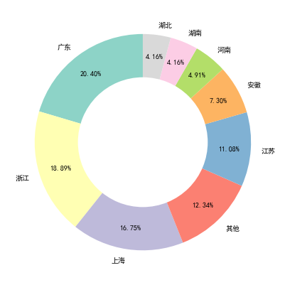

```python
#环形图
plt.figure(figsize=(7,7))
mask['店铺所在地'].value_counts().plot.pie(autopct = '%1.2f%%',startangle=90,pctdistance=0.8,colors=sns.color_palette("Set3", 10))
plt.pie([1],radius=0.6,colors='w') #内部白色饼图
plt.ylabel('')
plt.show()
```

### 相关性图

#### 相关性散点图

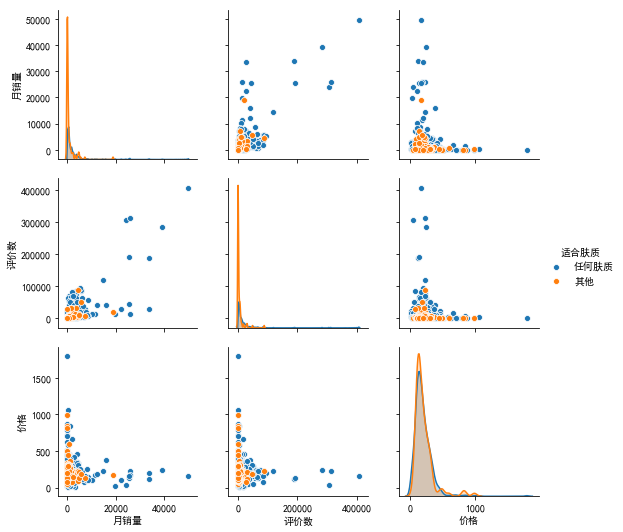

```python
sns.pairplot(mask[['月销量','评价数','价格','适合肤质']],hue='适合肤质')
```

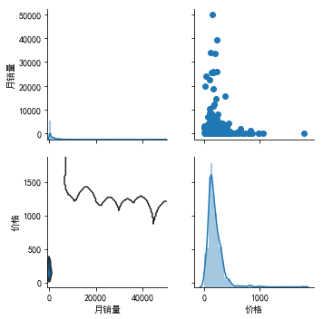

```python
g = sns.PairGrid(mask[['月销量','价格']])
g.map_diag(sns.distplot) #直方图
g.map_upper(plt.scatter) #散点图
g.map_lower(sns.kdeplot) #核密度曲线图
```

#### joint plot图

jointplot(x, y, data=None, kind='scatter', stat_func=None, color=None, height=6, ratio=5, space=0.2, dropna=True, xlim=None, ylim=None, joint_kws=None, marginal_kws=None, annot_kws=None, **kwargs)

kind : { "scatter" | "reg" | "resid" | "kde" | "hex" }

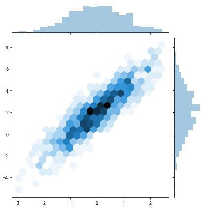

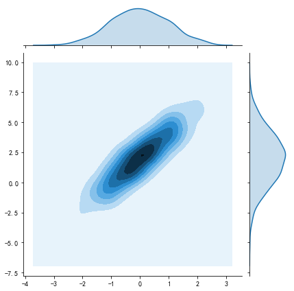

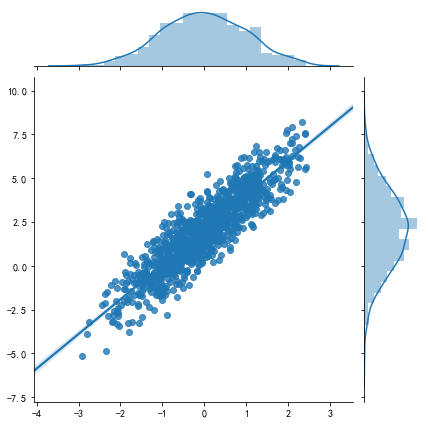

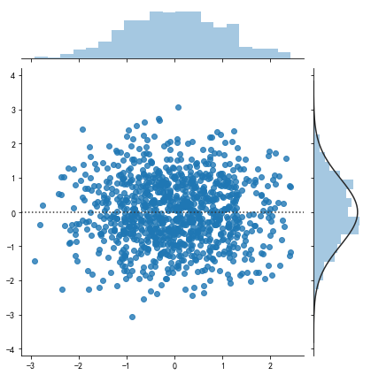

```python
x = np.random.normal(0,1,1000)
y = x*2+np.random.normal(2,1,1000)

fig=plt.figure(figsize=(3,3))
sns.jointplot(x,y,kind = 'hex')
sns.jointplot(x,y,kind = 'kde')
sns.jointplot(x,y,kind = 'reg')
sns.jointplot(x,y,kind = 'resid')
plt.show()
```

#### 相关性热力图

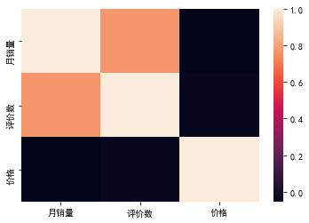

```python
sns.heatmap(mask[['月销量','评价数','价格']].corr())
```

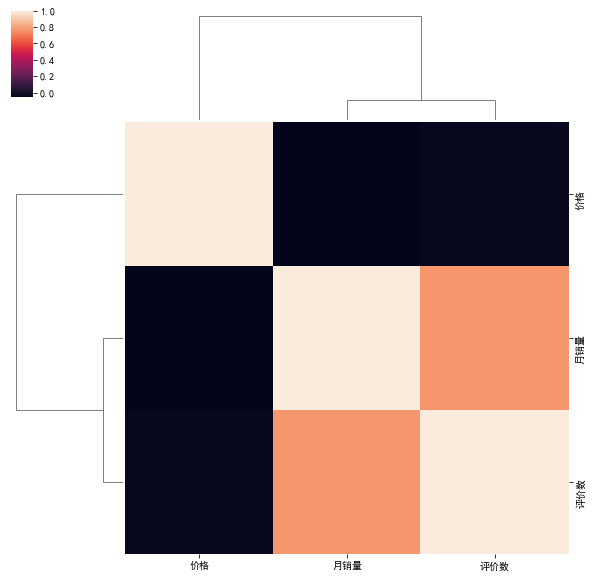

```python
# 分层相关性热力图
sns.clustermap(mask[['月销量','评价数','价格']].corr())
```

### 词云图

#### 爬取中文文本数据

```python
import requests
from bs4 import BeautifulSoup
```

```python
page = requests.get('http://www.un.org/zh/charter-united-nations/')
soup = BeautifulSoup(page.content, 'html.parser')  #解析网页
Link=soup.find_all("ul")[9].find_all("a")  #获取每条宪章的链接
UN = 'http://www.un.org/zh/'
hr=list()
for link in Link:
    hr.append(UN+link.get('href'))  #拼接链接
for i in range(len(hr)):
    hr[i]=hr[i].replace('../','')  #链接中的多余字符去掉
#爬取每条宪章的网页写入txt
with open("UNCharter.txt", "w",encoding='utf-8') as text_file:
    for k in range(len(hr)):
        r = requests.get(hr[k])
        sp = BeautifulSoup(r.content, 'html.parser')
        s_div=sp.find_all("section",class_="col-sm-9")[0]
        s_p=s_div.find_all({"h3","p"})
        for i in s_p:
            text_file.write(''.join(i.strings)+'\n')
```

```python
#读取文本数据
with open("UNCharter.txt",encoding='utf-8') as f:
    contents = f.read()
print("contents变量的类型：", type(contents))

contents[0:100]
```

```
contents变量的类型： <class 'str'>
```

```
'我联合国人民同兹决心\n并为达此目的\n用是发愤立志，务当同心协力，以竟厥功\n爰由我各本国政府，经齐集金山市之代表各将所奉全权证书，互相校阅，均属妥善，议定本联合国宪章，并设立国际组织，定名联合国。\n第一'
```

#### 分词画词云图

```python
import jieba
from wordcloud import WordCloud, STOPWORDS      #STOPWORDS为英文停用词
import matplotlib.pyplot as plt
import numpy as np
from imageio import imread                        #读取图像
```

```python
import re
txt1 = re.sub('[，：；\n \xa0 。、“”‘ ’]','',contents)  #【】正则表达式替换文本中的标点
```

```
(-0.5, 639.5, 599.5, -0.5)
```

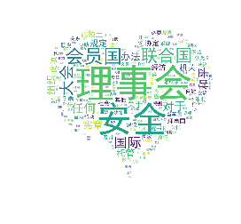

```python
# 使用jieba分词，获取词的列表,再用空格分隔拼接
txt2 = ' '.join(jieba.lcut(txt1))
#设置词云图对象属性
WC = WordCloud(font_path = 'C:\\Windows\\Fonts\\simhei.TTF',             #设置字体(中文必须设置)
               max_words=200,mask = imread('heart.jpeg',pilmode="RGB"),  #mask设置形状
               height= 1000,width=1000,collocations=False,              #collocations避免重复词
               background_color='white',mode='RGBA')
con = WC.generate(txt2)
con.to_file("ciyun.png")  #导出图片
plt.imshow(con)
plt.axis("off")  #不显示坐标轴
```

#### 英文词云图

```python
from nltk.corpus import stopwords
from nltk.tokenize import RegexpTokenizer
```

```python
txt = "Help on class WordCloud in module wordcloud.wordcloud: class WordCloud(builtins.object) WordCloud(font_path=None, width=400, height=200, margin=2, ranks_only=None, prefer_horizontal=0.9, mask=None, scale=1, color_func=None, max_words=200, min_font_size=4, stopwords=None, random_state=None, background_color='black', max_font_size=None, font_step=1, mode='RGB', relative_scaling='auto', regexp=None, collocations=True, colormap=None, normalize_plurals=True, contour_width=0, contour_color='black', repeat=False, include_numbers=False, min_word_length=0) Word cloud object for generating and drawing. Parameters font_path : string Font path to the font that will be used (OTF or TTF).Defaults to DroidSansMono path on a Linux machine. If you are on another OS or don't have this font, you need to adjust this path."
txt
```

[output not shown]

RegexpTokenizer分词

```
(-0.5, 639.5, 599.5, -0.5)
```

[figure not shown]

```python
#分词
tokenizer = RegexpTokenizer("[\w']+")
words = tokenizer.tokenize(txt)
#去停用词
english_stops = set(stopwords.words('english'))  #加载英文停用词
words = [word for word in words if word not in english_stops]  #去停用词
txt2 = ' '.join(words)
#设置词云图对象属性
WC = WordCloud(max_words=60,mask = imread('heart.jpeg',pilmode="RGB"),  #mask设置形状
               height= 1000,width=1000,collocations=False,              #collocations避免重复词
               background_color='white',mode='RGBA')
con = WC.generate(txt2)
con.to_file("E_ciyun.png")  #导出图片
plt.imshow(con)
plt.axis("off")  #不显示坐标轴
```

jieba 不好用

```
(-0.5, 639.5, 599.5, -0.5)
```

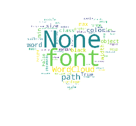

```python
txt2 = ' '.join(jieba.lcut(txt))
#设置词云图对象属性
WC = WordCloud(stopwords=english_stops.add("None"),max_words=60,        #设置停用词
               mask = imread('heart.jpeg',pilmode="RGB"),               #mask设置形状
               height= 1000,width=1000,collocations=False,              #collocations避免重复词
               background_color='white',mode='RGBA')
con = WC.generate(txt2)
#con.to_file("E_ciyun.png")  #导出图片
plt.imshow(con)
plt.axis("off")  #不显示坐标轴
```